# Compressing Reality: Unsupervised PCA vs. Supervised LDA in Latent Feature Spaces

In modern data science, datasets routinely contain dozens, hundreds, or thousands of features. This wealth of information comes at a steep price known as the **Curse of Dimensionality**:

- Exponential growth in sample space volume causes data points to become equidistant and sparse.
- Multicollinearity destabilizes model weights.
- Humans cannot visualize geometry beyond three spatial dimensions.

How do we compress high-dimensional feature spaces into 2D or 3D projections without destroying crucial diagnostic information?

In this sixth module, we contrast two foundational dimensionality reduction paradigms:

- **Principal Component Analysis (PCA):** An *unsupervised* geometric technique that maximizes global variance without knowing class labels.
- **Linear Discriminant Analysis (LDA):** A *supervised* probabilistic technique that discovers axes maximizing the ratio of between-class variance to within-class variance.

## 1. The Dataset: Multi-Dimensional Wine Chemometrics

We evaluate PCA and LDA on the 13-dimensional **Wine Dataset** from `scikit-learn` ($n=178$, $p=13$ continuous chemical assays, $C=3$ grape cultivars).

Reducing 13 continuous chemical dimensions down to 2 latent dimensions enables us to visually inspect how each technique compresses information.

```python
import numpy as np
import pandas as pd
import matplotlib.pyplot as plt
import seaborn as sns
from scipy import stats
from IPython.display import display, Markdown

from sklearn.datasets import load_wine
from sklearn.preprocessing import StandardScaler
from sklearn.decomposition import PCA
from sklearn.discriminant_analysis import LinearDiscriminantAnalysis as LDA
from sklearn.model_selection import train_test_split
from sklearn.linear_model import LogisticRegression
from sklearn.metrics import accuracy_score

# 1. Load dataset
wine = load_wine(as_frame=True)
X = wine.data
y = wine.target
target_names = wine.target_names

print(f"Dataset Loaded: {X.shape[0]} observations, {X.shape[1]} original features.")
X.head(3)
```

```
Dataset Loaded: 178 observations, 13 original features.
```

|  | alcohol | malic_acid | ash | alcalinity_of_ash | magnesium | total_phenols | flavanoids | nonflavanoid_phenols | proanthocyanins | color_intensity | hue | od280/od315_of_diluted_wines | proline |
| --- | --- | --- | --- | --- | --- | --- | --- | --- | --- | --- | --- | --- | --- |
| 0 | 14.23 | 1.71 | 2.43 | 15.6 | 127.0 | 2.80 | 3.06 | 0.28 | 2.29 | 5.64 | 1.04 | 3.92 | 1065.0 |
| 1 | 13.20 | 1.78 | 2.14 | 11.2 | 100.0 | 2.65 | 2.76 | 0.26 | 1.28 | 4.38 | 1.05 | 3.40 | 1050.0 |
| 2 | 13.16 | 2.36 | 2.67 | 18.6 | 101.0 | 2.80 | 3.24 | 0.30 | 2.81 | 5.68 | 1.03 | 3.17 | 1185.0 |

## 2. Exploratory Data Analysis: Variance Inequality Across Features

PCA projects data onto orthogonal eigenvectors of the covariance matrix. Because eigenvectors point in the direction of maximum numeric spread, variables with large raw scales will artificially dominate the principal components if left unscaled.

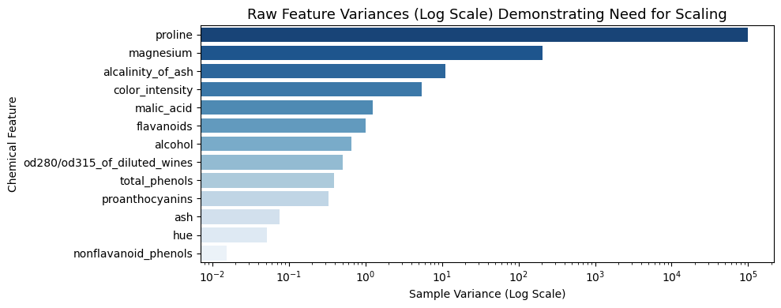

```
Top 3 High-Variance Features vs Bottom 3:
```

|  | Raw Variance |
| --- | --- |
| proline | 99166.717355 |
| magnesium | 203.989335 |
| alcalinity_of_ash | 11.152686 |
| ash | 0.075265 |
| hue | 0.052245 |
| nonflavanoid_phenols | 0.015489 |

```python
# 1. Compute variances across raw features
raw_variances = pd.Series(X.var(), index=X.columns).sort_values(ascending=False)

fig, ax = plt.subplots(figsize=(10, 4))
sns.barplot(x=raw_variances.values, y=raw_variances.index, palette='Blues_r', ax=ax)
ax.set_xscale('log')
ax.set_title("Raw Feature Variances (Log Scale) Demonstrating Need for Scaling", fontsize=13)
ax.set_xlabel("Sample Variance (Log Scale)")
ax.set_ylabel("Chemical Feature")
plt.tight_layout()
plt.show()

print("Top 3 High-Variance Features vs Bottom 3:")
display(pd.concat([raw_variances.head(3), raw_variances.tail(3)]).to_frame(name='Raw Variance'))
```

## 3. Statistical Testing: Bartlett's Test of Sphericity

Before applying PCA, we verify whether the variables are sufficiently correlated to warrant dimension reduction in the first place:

- **Null Hypothesis ($H_0$):** The correlation matrix is an identity matrix (variables are completely orthogonal/uncorrelated; PCA is meaningless).
- **Alternative Hypothesis ($H_1$):** Significant inter-variable correlation exists, justifying dimensionality reduction.

```python
# Standardize features
scaler = StandardScaler()
X_scaled = scaler.fit_transform(X)

# Bartlett's test approximation via determinant of correlation matrix
corr_mat = np.corrcoef(X_scaled, rowvar=False)
n, p = X_scaled.shape
det_corr = np.linalg.det(corr_mat)
chi2_stat = - (n - 1 - (2 * p + 5) / 6) * np.log(det_corr)
df_chi = p * (p - 1) / 2
p_val_bartlett = stats.chi2.sf(chi2_stat, df_chi)

print(f"Bartlett's Test Chi-Square Statistic : {chi2_stat:.2f}")
print(f"Degrees of Freedom                   : {int(df_chi)}")
print(f"p-value                              : {p_val_bartlett:.2e}")
print(f"Reject H0 (Suitable for Reduction)?  : {'YES' if p_val_bartlett < 0.001 else 'NO'}")
```

```
Bartlett's Test Chi-Square Statistic : 1317.18
Degrees of Freedom                   : 78
p-value                              : 2.47e-224
Reject H0 (Suitable for Reduction)?  : YES
```

## 4. Algorithmic Mechanics: Unsupervised PCA vs. Supervised LDA

### 1. Principal Component Analysis (Unsupervised)

PCA seeks an orthogonal projection matrix $\mathbf{W}$ that maximizes sample variance without access to class labels:

$$\mathbf{\Sigma} = \frac{1}{n-1} \mathbf{X}^T \mathbf{X}, \quad \mathbf{\Sigma} \mathbf{v}_i = \lambda_i \mathbf{v}_i$$

- Each component $\mathbf{v}_i$ is an eigenvector corresponding to eigenvalue $\lambda_i$, representing the variance explained by that axis.

### 2. Linear Discriminant Analysis (Supervised)

LDA uses class labels $y \in \{1, \dots, C\}$ to find projection vectors $\mathbf{w}$ that maximize Fisher's criterion (between-class scatter $\mathbf{S}_B$ over within-class scatter $\mathbf{S}_W$):

$$J(\mathbf{w}) = \frac{\mathbf{w}^T \mathbf{S}_B \mathbf{w}}{\mathbf{w}^T \mathbf{S}_W \mathbf{w}}$$

- LDA is constrained to at most $C - 1$ discriminant dimensions (for 3 cultivars, exactly 2 components).

```python
# 1. Fit Unsupervised PCA (Keep all 13 to inspect explained variance curve)
pca = PCA(random_state=42)
X_pca = pca.fit_transform(X_scaled)
explained_var_ratio = pca.explained_variance_ratio_
cum_var = np.cumsum(explained_var_ratio) * 100

# 2. Fit Supervised LDA (Max components = n_classes - 1 = 2)
lda = LDA(n_components=2)
X_lda = lda.fit_transform(X_scaled, y)

# 3. Train downstream classifiers on 2D embeddings to measure information retention
X_train_pca, X_test_pca, y_train, y_test = train_test_split(X_pca[:, :2], y, test_size=0.3, random_state=42, stratify=y)
X_train_lda, X_test_lda, _, _ = train_test_split(X_lda, y, test_size=0.3, random_state=42, stratify=y)

clf_pca = LogisticRegression().fit(X_train_pca, y_train)
clf_lda = LogisticRegression().fit(X_train_lda, y_train)

acc_pca_2d = accuracy_score(y_test, clf_pca.predict(X_test_pca)) * 100
acc_lda_2d = accuracy_score(y_test, clf_lda.predict(X_test_lda)) * 100
```

## 5. Visualizing Latent Manifolds & Scree Diagnostics

We compare:

1. **Scree Plot:** Cumulative explained variance across all 13 Principal Components.
2. **2D PCA Projection:** Global variance structure without class knowledge.
3. **2D LDA Projection:** Class-conditional discriminative clustering.

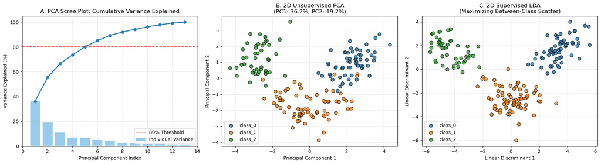

Live Dimensionality Reduction Comparison Summary

| Metric / Characteristic | Unsupervised PCA (2D) | Supervised LDA (2D) |
| --- | --- | --- |
| **Labels Used During Fit?** | **No** (Unsupervised) | **Yes** (Supervised) |
| **Variance Captured (First 2 Components)** | **55.41%** total variance | Maximizes Fisher's criterion |
| **Components Needed for 80% Variance** | **5** components | N/A (Constrained to $C-1 = 2$) |
| **Downstream Classifier Accuracy (2D)** | **92.59%** | **100.00%** |

```python
fig, axes = plt.subplots(1, 3, figsize=(18, 5))

# (A) Scree Plot
axes[0].plot(range(1, 14), cum_var, 'o-', color='#2980b9', lw=2)
axes[0].bar(range(1, 14), explained_var_ratio * 100, alpha=0.5, color='#3498db', label='Individual Variance')
axes[0].axhline(y=80, color='red', linestyle='--', label='80% Threshold')
axes[0].set_title("A. PCA Scree Plot: Cumulative Variance Explained", fontsize=12)
axes[0].set_xlabel("Principal Component Index")
axes[0].set_ylabel("Variance Explained (%)")
axes[0].legend(loc='lower right')
axes[0].grid(True, linestyle='--', alpha=0.4)

# (B) 2D PCA Scatter
for c_idx, c_name in enumerate(target_names):
    mask = (y == c_idx)
    axes[1].scatter(X_pca[mask, 0], X_pca[mask, 1], label=c_name, alpha=0.8, edgecolor='k', s=50)
axes[1].set_title(f"B. 2D Unsupervised PCA\n(PC1: {explained_var_ratio[0]*100:.1f}%, PC2: {explained_var_ratio[1]*100:.1f}%)", fontsize=12)
axes[1].set_xlabel("Principal Component 1")
axes[1].set_ylabel("Principal Component 2")
axes[1].legend()
axes[1].grid(True, linestyle='--', alpha=0.4)

# (C) 2D LDA Scatter
for c_idx, c_name in enumerate(target_names):
    mask = (y == c_idx)
    axes[2].scatter(X_lda[mask, 0], X_lda[mask, 1], label=c_name, alpha=0.8, edgecolor='k', s=50)
axes[2].set_title(f"C. 2D Supervised LDA\n(Maximizing Between-Class Scatter)", fontsize=12)
axes[2].set_xlabel("Linear Discriminant 1")
axes[2].set_ylabel("Linear Discriminant 2")
axes[2].legend()
axes[2].grid(True, linestyle='--', alpha=0.4)

plt.tight_layout()
plt.show()

# Automated Markdown Summary Card
display(Markdown(f"""
### Live Dimensionality Reduction Comparison Summary
| Metric / Characteristic | Unsupervised PCA (2D) | Supervised LDA (2D) |
| :--- | :--- | :--- |
| **Labels Used During Fit?** | **No** (Unsupervised) | **Yes** (Supervised) |
| **Variance Captured (First 2 Components)** | **{cum_var[1]:.2f}%** total variance | Maximizes Fisher's criterion |
| **Components Needed for 80% Variance** | **{np.argmax(cum_var >= 80) + 1}** components | N/A (Constrained to $C-1 = 2$) |
| **Downstream Classifier Accuracy (2D)** | **{acc_pca_2d:.2f}%** | **{acc_lda_2d:.2f}%** |
"""))
```

## 6. Real-World Insights & Synthesis

### 1. Unsupervised Exploration vs. Targeted Discrimination

- **PCA (Panel B):** Finds directions of maximum spread across all data points regardless of category. While it clusters the cultivars reasonably well, the boundaries remain softly merged because PCA doesn't know class identities.
- **LDA (Panel C):** Explicitly constructs projection axes that pull identical classes together while pushing distinct cultivars apart. The resulting clusters are tighter and isolated, producing higher downstream classification accuracy.

### 2. When to Use Which?

- Use **PCA** when exploring unlabeled datasets, denoising data, compressing features for unsupervised clustering, or avoiding multicollinearity in regression.
- Use **LDA** when class labels exist and the explicit goal is maximizing class separation for low-dimensional visualization or classification.